# Ya pasó el pico en la Argentina

Daniel Gervini

8 de noviembre de 2020

# Evolución del coronavirus en las regiones más pobladas

La mayor parte de la población argentina se concentra en la Capital Federal y en las provincias de Buenos Aires, Córdoba y Sante Fe. Por lo tanto, la evolución del total de casos en la Argentina es mayormente la sumatoria de estas cuatro regiones. El resto de las provincias aporta relativamente poco al total de casos, así que el pico de casos nacionales habrá pasado cuando hayan pasado los picos en las cuatro regiones más pobladas, aunque en otras provincias todavía haya crecimiento de casos.

En este posteo repasamos la evolución del coronavirus en estas cuatro regiones. En posteos anteriores de hace más de dos meses ([acá](https://dgervini.github.io/Coronavirus/Chequeando_predicciones.html) y [acá](https://dgervini.github.io/Coronavirus/Pico_provincia.html)), ya habíamos visto que el pico había pasado en Capital Federal y estaba pasando en Provincia de Buenos Aires, y [en este posteo](https://dgervini.github.io/Coronavirus/Cordoba_Rosario.html) habíamos hecho proyecciones sobre la ocurrencia del pico en Rosario y Córdoba Capital. Como vemos abajo, la tendencia al descenso en Capital Federal y Provincia de Buenos Aires ha seguido marcadamente en los últimos dos meses, y los totales provinciales para Córdoba y Santa Fe están en línea con las proyecciones que habíamos hecho para sus ciudades capitales (es decir, que los picos llegarían entre mediados de octubre y principios de noviembre).

## Capital Federal

Los gráficos de abajo muestran los casos confirmados y muertes diarias para la ciudad de Buenos Aires (los círculos negros son los datos y la línea roja es una curva de suavizado, para ver mejor la tendencia). Se ve claramente que la tendencia a la baja continúa desde agosto.

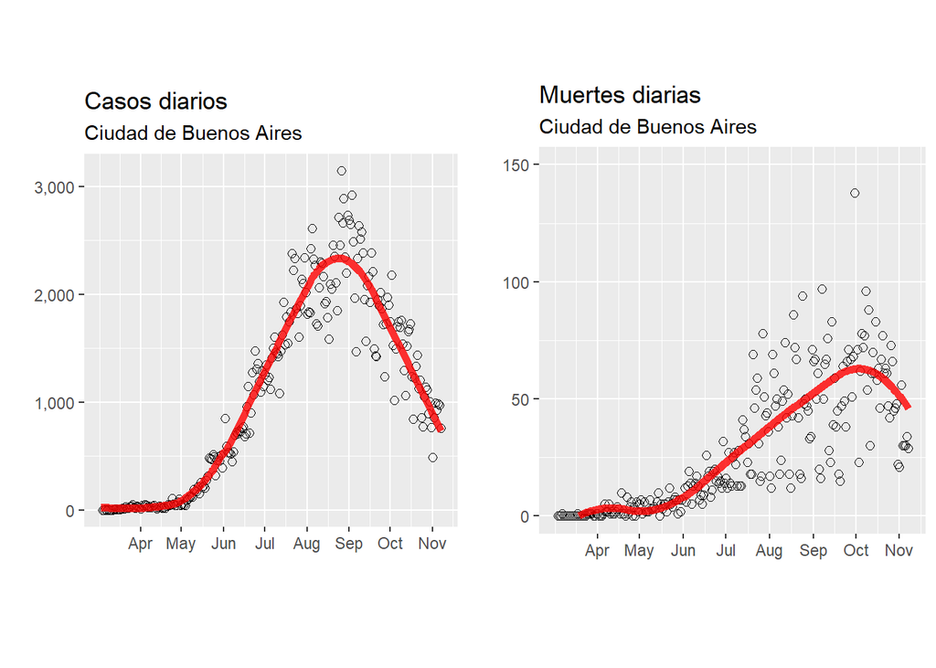

## Provincia de Buenos Aires

Los gráficos de casos y muertes diarias para la Provincia de Buenos Aires también siguen mostrando una clara tendencia a la baja desde el pico en septiembre.

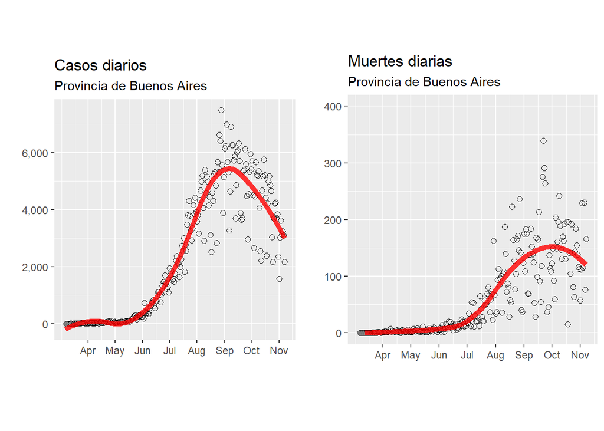

## Provincia de Santa Fe

Los gráficos de abajo muestran que, en línea con lo que habíamos previsto en [este posteo](https://dgervini.github.io/Coronavirus/Cordoba_Rosario.html), el pico de casos diarios para Santa Fe ocurrió a mediados de octubre y ahora los casos (aunque aún no las muertes) muestran una tendencia a la baja.

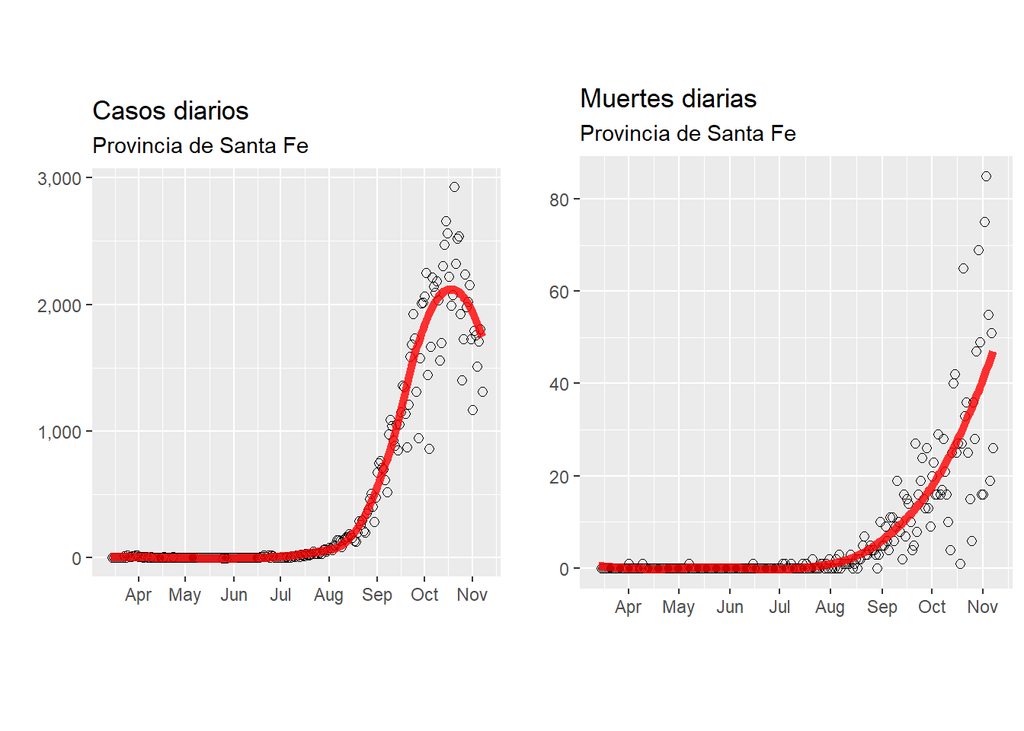

## Provincia de Córdoba

Los gráficos de abajo muestran que los casos diarios, e incluso las muertes diarias, ya alcanzaron el pico en la Provincia de Córdoba, un poco antes de lo que habíamos previsto en [este posteo](https://dgervini.github.io/Coronavirus/Cordoba_Rosario.html).

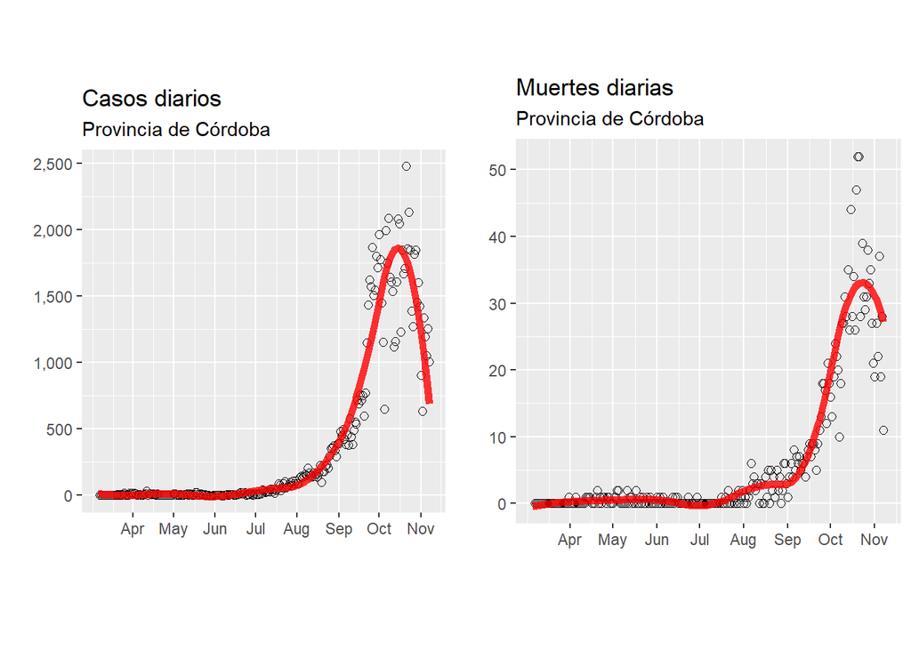

# Total nacional

Los gráficos del total nacional de casos diarios y muertes diarias que se ven a continuación muestran que el pico nacional ocurrió a mediados de octubre.

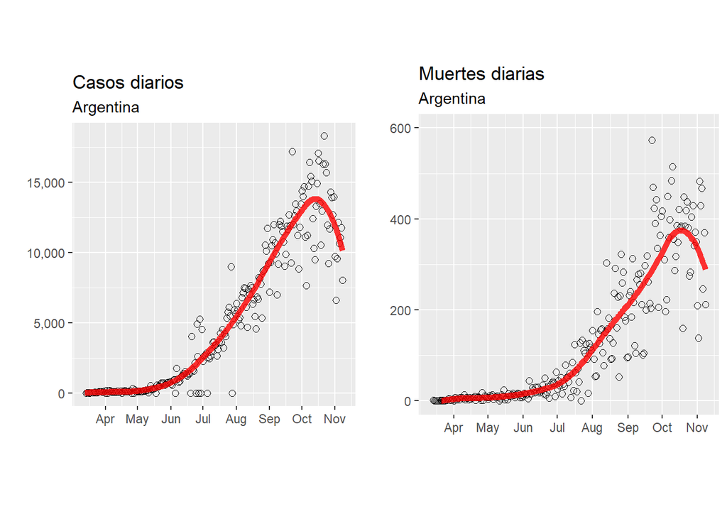

# Conclusiones

Dado que los picos de casos diarios en la Capital Federal y las tres provincias más pobladas del país ya pasaron, podemos concluir que la tendencia a la baja en el total de casos diarios nacionales, que se ha observado claramente en las últimas semanas, se va a consolidar y el pico de casos diarios en la Argentina ocurrió a mediados de octubre.

[Back to blog](https://sites.uwm.edu/gervini/coronavirus-blog/)